# Change in Number of Deaths From AIDS

# The Basics: Univariate Analyses

```
##         Country         year                 n
##  Afghanistan:  22   Length:3132        Min.   :    60
##  Armenia    :  22   Class :character   1st Qu.:    60
##  Australia  :  22   Mode  :character   Median :   350
##  Austria    :  22                      Mean   :  9050
##  Azerbaijan :  22                      3rd Qu.:  3700
##  Bahamas    :  22                      Max.   :390000
##  (Other)    :3000
```

```
##                   Country         1990            1991
##  Abkhazia             :  1   Min.   :   60   Min.   :   60
##  Afghanistan          :  1   1st Qu.:   60   1st Qu.:   60
##  Akrotiri and Dhekelia:  1   Median :  120   Median :  150
##  Åland                :  1   Mean   : 2150   Mean   : 2687
##  Albania              :  1   3rd Qu.:  600   3rd Qu.: 1050
##  Algeria              :  1   Max.   :85000   Max.   :95000
##  (Other)              :263   NA's   :122     NA's   :122
##       1992             1993             1994             1995
##  Min.   :    60   Min.   :    60   Min.   :    60   Min.   :    60
##  1st Qu.:    60   1st Qu.:    60   1st Qu.:    60   1st Qu.:    60
##  Median :   300   Median :   350   Median :   350   Median :   350
##  Mean   :  3300   Mean   :  4064   Mean   :  4876   Mean   :  5786
##  3rd Qu.:  1350   3rd Qu.:  1850   3rd Qu.:  2300   3rd Qu.:  3100
##  Max.   :100000   Max.   :110000   Max.   :110000   Max.   :110000
##  NA's   :122      NA's   :122      NA's   :122      NA's   :122
##       1996             1997             1998             1999
##  Min.   :    60   Min.   :    60   Min.   :    60   Min.   :    60
##  1st Qu.:    60   1st Qu.:    60   1st Qu.:    60   1st Qu.:    60
##  Median :   350   Median :   350   Median :   350   Median :   600
##  Mean   :  6712   Mean   :  7490   Mean   :  8423   Mean   :  9462
##  3rd Qu.:  3550   3rd Qu.:  3350   3rd Qu.:  3900   3rd Qu.:  4750
##  Max.   :110000   Max.   :110000   Max.   :120000   Max.   :140000
##  NA's   :122      NA's   :122      NA's   :122      NA's   :122
##       2000             2001             2002             2003
##  Min.   :    60   Min.   :    60   Min.   :    60   Min.   :    60
##  1st Qu.:    60   1st Qu.:    60   1st Qu.:    90   1st Qu.:   120
##  Median :   600   Median :   600   Median :   600   Median :   600
##  Mean   : 10383   Mean   : 11335   Mean   : 12280   Mean   : 12985
##  3rd Qu.:  5650   3rd Qu.:  6150   3rd Qu.:  6650   3rd Qu.:  6550
##  Max.   :160000   Max.   :210000   Max.   :260000   Max.   :300000
##  NA's   :122      NA's   :122      NA's   :122      NA's   :122
##       2004             2005             2006             2007
##  Min.   :    60   Min.   :    60   Min.   :    60   Min.   :    60
##  1st Qu.:   135   1st Qu.:   150   1st Qu.:   150   1st Qu.:   150
##  Median :   600   Median :   600   Median :   600   Median :   600
##  Mean   : 13438   Mean   : 13598   Mean   : 13502   Mean   : 13040
##  3rd Qu.:  6550   3rd Qu.:  6150   3rd Qu.:  5550   3rd Qu.:  5300
##  Max.   :340000   Max.   :370000   Max.   :390000   Max.   :390000
##  NA's   :122      NA's   :122      NA's   :122      NA's   :122
##       2008             2009             2010             2011
##  Min.   :    60   Min.   :    60   Min.   :    60   Min.   :    60
##  1st Qu.:   150   1st Qu.:   150   1st Qu.:   150   1st Qu.:   150
##  Median :   600   Median :   800   Median :   350   Median :   350
##  Mean   : 12443   Mean   : 11709   Mean   : 10434   Mean   :  9706
##  3rd Qu.:  5400   3rd Qu.:  5725   3rd Qu.:  2850   3rd Qu.:  2825
##  Max.   :380000   Max.   :340000   Max.   :300000   Max.   :270000
##  NA's   :122      NA's   :121      NA's   :174      NA's   :173
```

Summaries of tidied (top) and untidied (bottom) data.

The majority of countries have low death numbers relative to each other; the median is always very far below the mean. For this project, I’m generally more interested in countries with numbers above the mean.

```
##          Country        1990            1991            1992
##  Argentina   : 1   Min.   :   60   Min.   :   60   Min.   :    60
##  Botswana    : 1   1st Qu.: 1075   1st Qu.: 1575   1st Qu.:  2100
##  Brazil      : 1   Median : 3000   Median : 3600   Median :  5850
##  Burkina Faso: 1   Mean   : 8148   Mean   :10172   Mean   : 12473
##  Burundi     : 1   3rd Qu.: 7050   3rd Qu.: 8275   3rd Qu.: 12000
##  Cameroon    : 1   Max.   :85000   Max.   :95000   Max.   :100000
##  (Other)     :32   NA's   :2       NA's   :2       NA's   :2
##       1993             1994             1995             1996
##  Min.   :    60   Min.   :    60   Min.   :    60   Min.   :    60
##  1st Qu.:  3050   1st Qu.:  3600   1st Qu.:  4325   1st Qu.:  5250
##  Median :  6800   Median :  8000   Median :  8850   Median : 10500
##  Mean   : 15342   Mean   : 18336   Mean   : 21717   Mean   : 25171
##  3rd Qu.: 16500   3rd Qu.: 25250   3rd Qu.: 34500   3rd Qu.: 41250
##  Max.   :110000   Max.   :110000   Max.   :110000   Max.   :110000
##  NA's   :2        NA's   :2        NA's   :2        NA's   :2
##       1997             1998             1999             2000
##  Min.   :    60   Min.   :    60   Min.   :    60   Min.   :    60
##  1st Qu.:  5125   1st Qu.:  5975   1st Qu.:  6675   1st Qu.:  7525
##  Median : 11500   Median : 11500   Median : 12500   Median : 14000
##  Mean   : 28096   Mean   : 31513   Mean   : 35382   Mean   : 38768
##  3rd Qu.: 46000   3rd Qu.: 48500   3rd Qu.: 55000   3rd Qu.: 56750
##  Max.   :110000   Max.   :120000   Max.   :140000   Max.   :160000
##  NA's   :2        NA's   :2        NA's   :2        NA's   :2
##       2001             2002             2003             2004
##  Min.   :   150   Min.   :   350   Min.   :   600   Min.   :   600
##  1st Qu.:  8625   1st Qu.:  7750   1st Qu.:  8150   1st Qu.:  9525
##  Median : 15000   Median : 15500   Median : 16500   Median : 17000
##  Mean   : 42362   Mean   : 45940   Mean   : 48597   Mean   : 50336
##  3rd Qu.: 54750   3rd Qu.: 55750   3rd Qu.: 61250   3rd Qu.: 66250
##  Max.   :210000   Max.   :260000   Max.   :300000   Max.   :340000
##  NA's   :2        NA's   :2        NA's   :2        NA's   :2
##       2005             2006             2007             2008
##  Min.   :   600   Min.   :   600   Min.   :   600   Min.   :   600
##  1st Qu.: 10575   1st Qu.:  9975   1st Qu.:  9075   1st Qu.:  7825
##  Median : 17500   Median : 16500   Median : 15500   Median : 14500
##  Mean   : 50903   Mean   : 50617   Mean   : 48844   Mean   : 46553
##  3rd Qu.: 66500   3rd Qu.: 63500   3rd Qu.: 53750   3rd Qu.: 47000
##  Max.   :370000   Max.   :390000   Max.   :390000   Max.   :380000
##  NA's   :2        NA's   :2        NA's   :2        NA's   :2
##       2009             2010             2011
##  Min.   :   600   Min.   :   600   Min.   :   600
##  1st Qu.:  7100   1st Qu.:  7300   1st Qu.:  7225
##  Median : 15000   Median : 17000   Median : 15500
##  Mean   : 42857   Mean   : 53653   Mean   : 47539
##  3rd Qu.: 45000   3rd Qu.: 66000   3rd Qu.: 54500
##  Max.   :340000   Max.   :300000   Max.   :270000
##  NA's   :1        NA's   :21       NA's   :20
```

This is a summary the dataset when it’s made up only of countries that have at least one year where they were above the mean. In other words, excluding countries that are consistently below the mean.

# Countries with high death totals

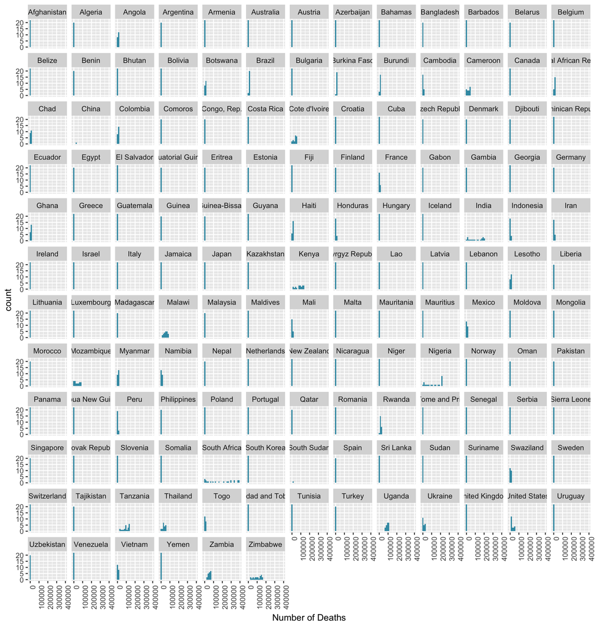

Faceting the data by country shows that there is at least some kind of change over time in many countries, even those that stay well below the median.

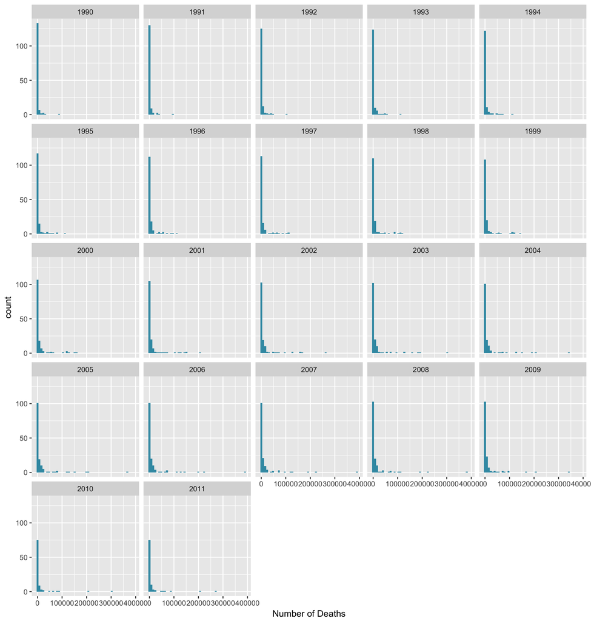

These graphs are the count of yearly death totals broken out by year for the entire dataset, not just those countries above the mean.

Notable elements include: starting in about 1999, more countries have higher death rates.

2010 and 2011 have significantly fewer records than in previous years.

Although the introduction of AZT in the 90’s began the dramatic decrease of rate of deaths from AIDS, the highest single-year rates are found in the late 2000’s. This could be due to better reporting/communication, or an indication of global inequalities in access to medicine.

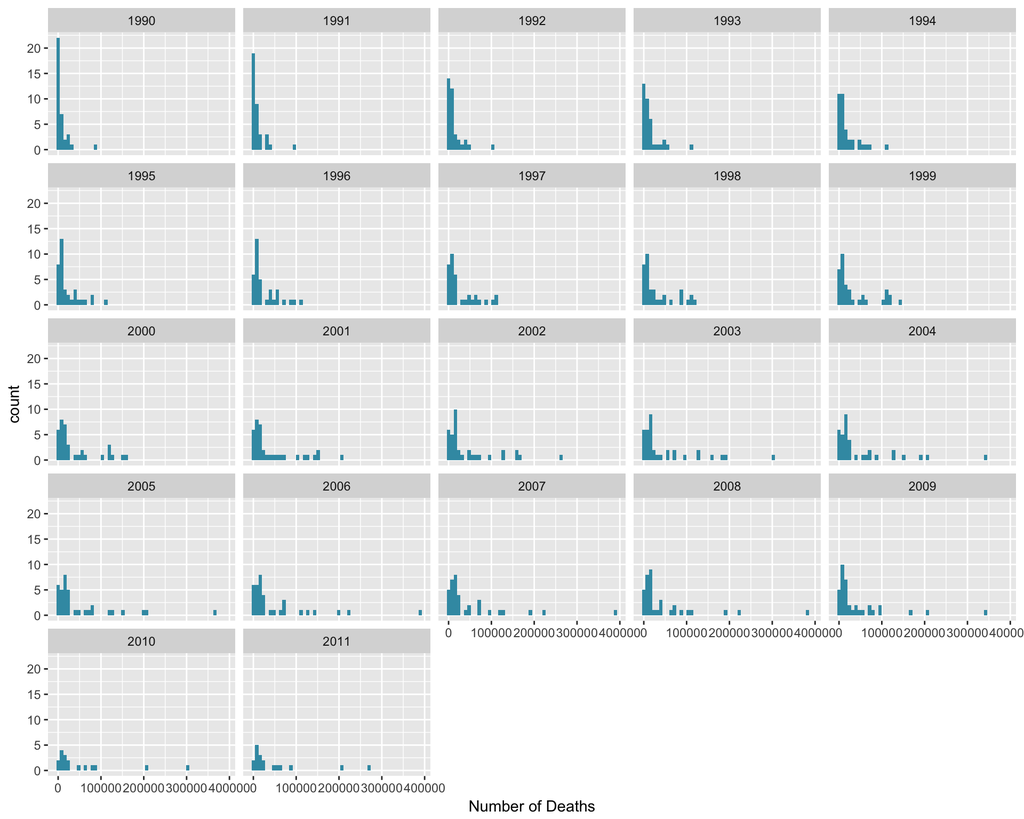

The same graph as above, but using the dataset of countries with at least one year above the mean.

Although most countries are still reporting deaths on the lower end of the scale, a little more variation is visible, particularly after the late 90’s, as compared to the dataset of all countries.

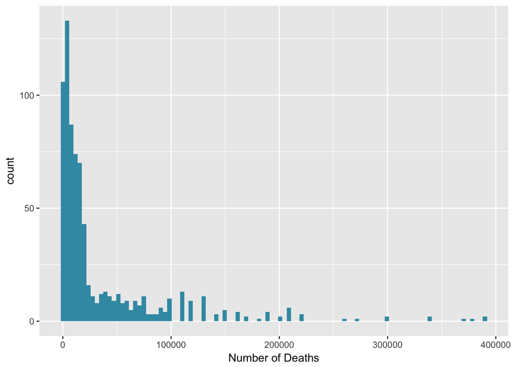

Histograms for number of cases in all countries that have at least one year above the mean number of deaths.

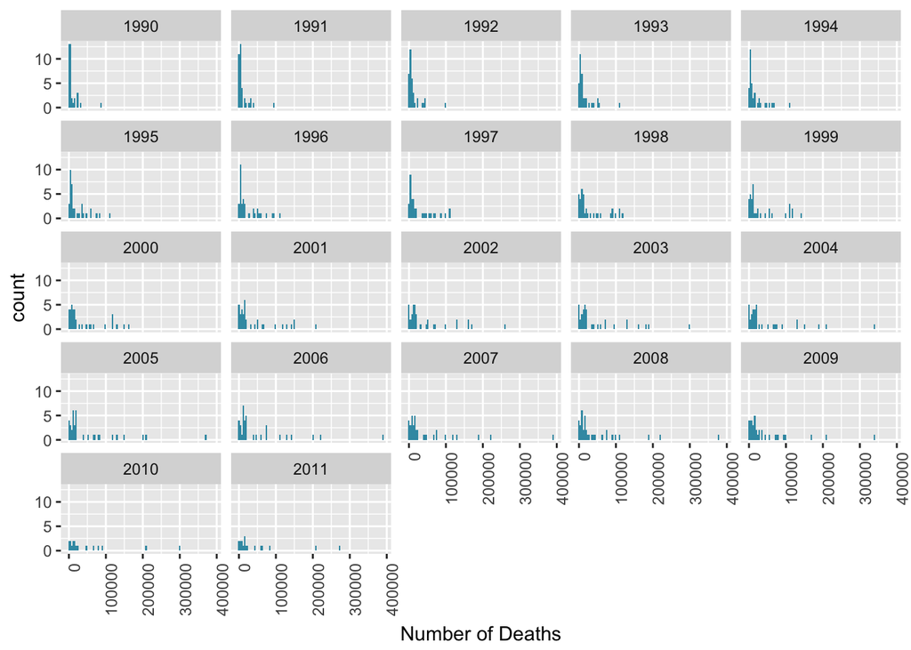

As above, broken out by year.

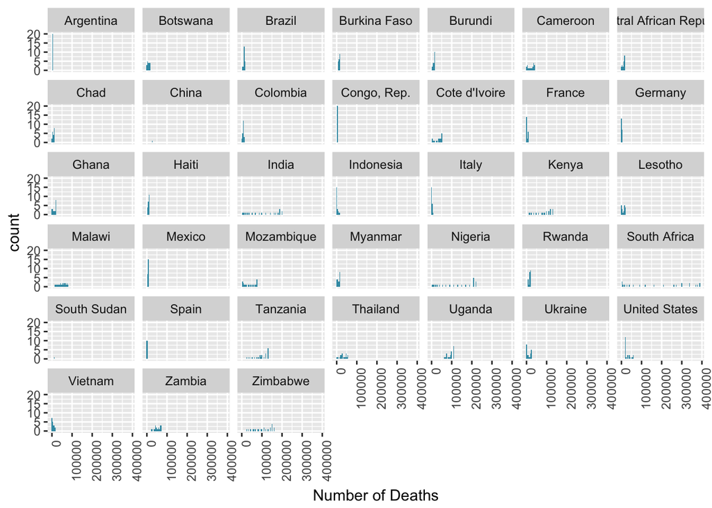

And broken out by country.

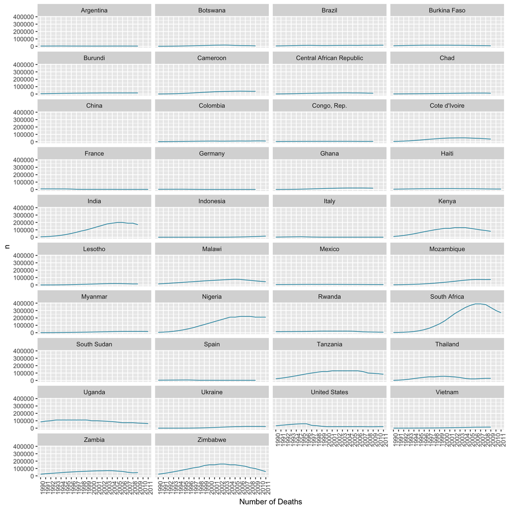

Despite the introduction of AZT in the 90’s, many countries saw increases in reported deaths throughout that decade, likely reflecting differences in medical access.

# Trends over two decades

```
##         Country         1990            2000
##  Afghanistan:  1   Min.   :   60   Min.   :    60
##  Algeria    :  1   1st Qu.:   60   1st Qu.:    60
##  Angola     :  1   Median :  120   Median :   600
##  Argentina  :  1   Mean   : 2150   Mean   : 10383
##  Armenia    :  1   3rd Qu.:  600   3rd Qu.:  5650
##  Australia  :  1   Max.   :85000   Max.   :160000
##  (Other)    :141
```

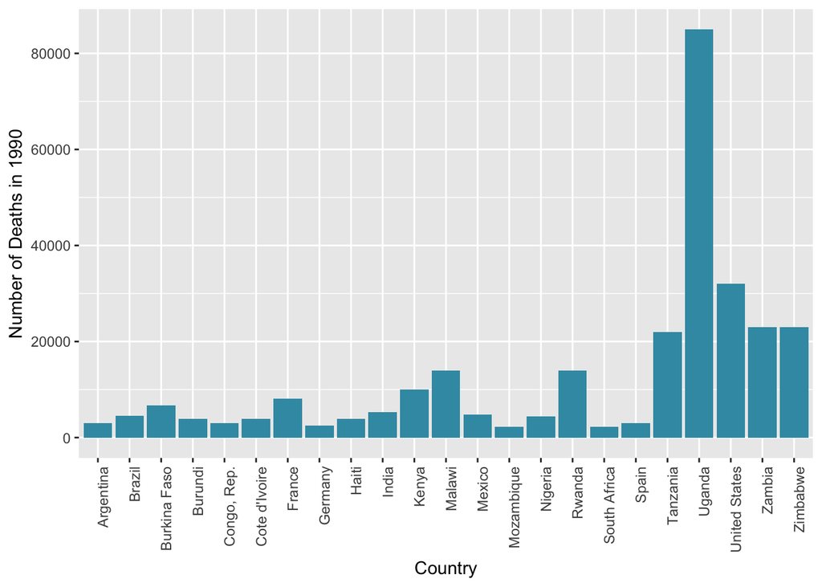

This graph shows the number of deaths from AIDS in 1990, for countries with deaths above the mean in 1990.

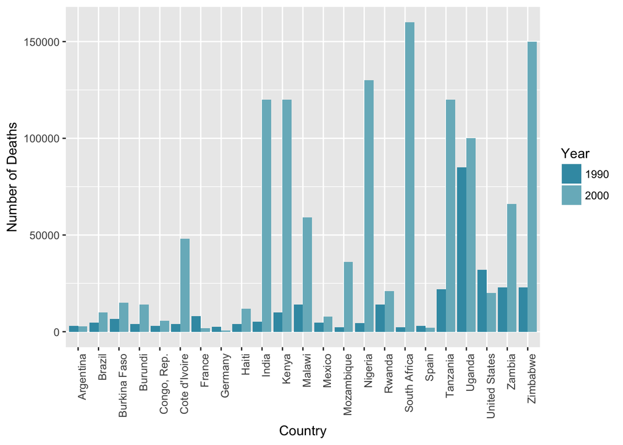

Comparing 1990 to 2000, again with only the set of countries above the mean in 1990

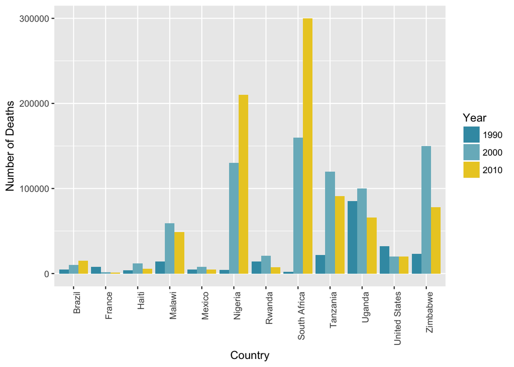

Tracing number of deaths from AIDS from 1990, 2000, and 2010, for countries above the mean number of deaths in 1990.

Out of 12 countries surveyed, 10 saw an increase from 1990 to 2000, while only 3 saw an increase between 2000 and 2010.

# Year on Year Changes

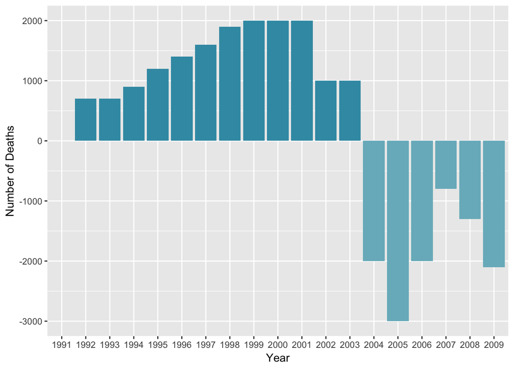

Change in number of deaths in an above-mean country chosen at random (Botswana).

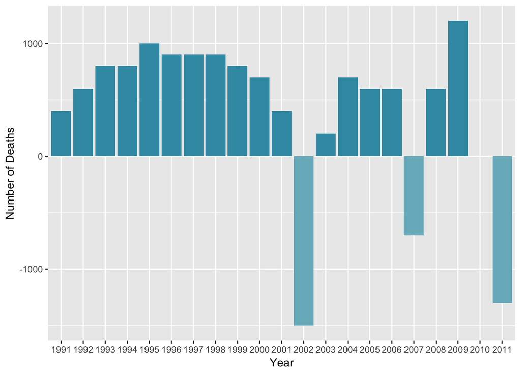

Changes in Colombia.

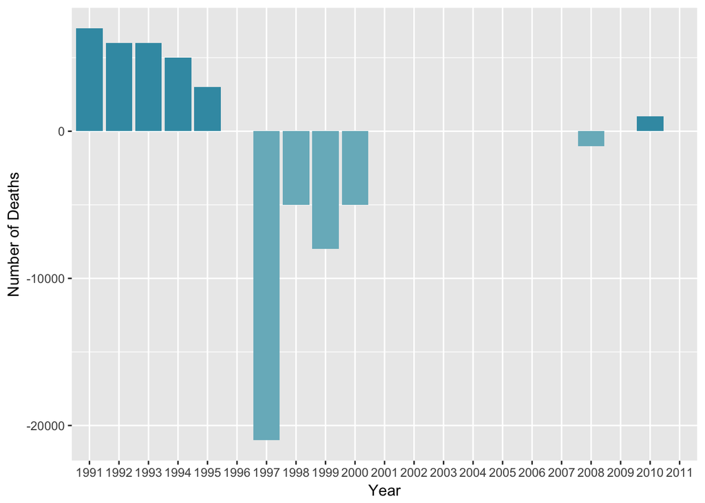

United States

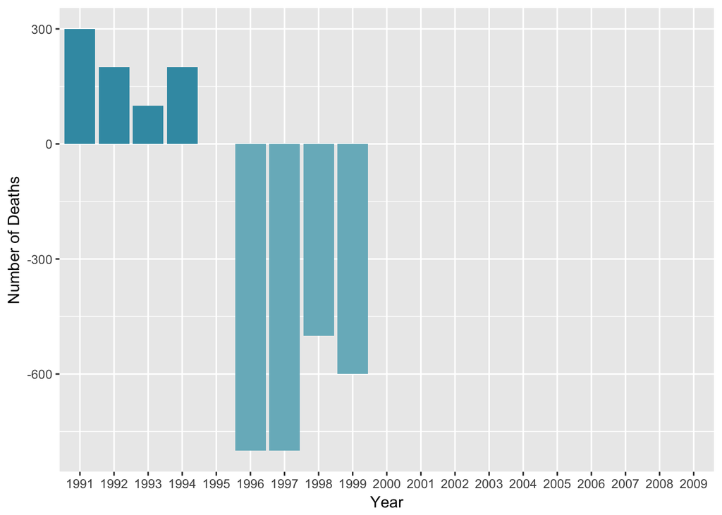

Germany

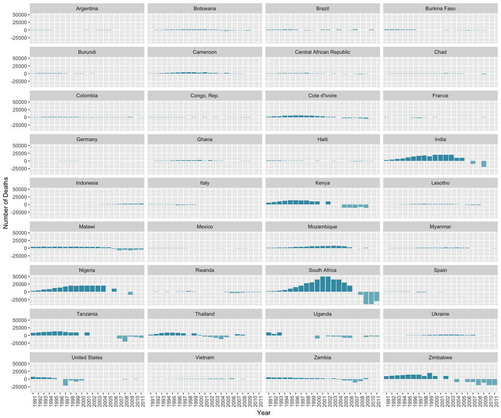

# Final Analysis

The first published report identifying HIV/AIDS was published in June 1981. The AIDS epidemic ripped through the globe in the next decade, government mismanagement and fear limiting education and research until the 1990’s and the advent of AZT and similar drugs. This data from WHO illustrates the story of the treatment of HIV and AIDS over two decades, from becoming a death sentence to a disease that is treatable and (less) stigmatized.